# Quarto Dia - Rodando Alguns Modelos

Pedro Cavalcante

20 de fevereiro de 2019

Agora que cobrimos manipulação, importação, limpeza e exploração de dados, podemos finalmente analisa-los. Hoje vamos cobrir algumas rotinas estatísticas, como roda-las e executar alguns testes de diagnósticos. Vamos usar algumas bases de dados do pacote `wooldridge`, então o tenha instalado.

# Um primeiro exemplo de regressão linear

Começaremos com um exemplo de dados simulados, em que conhecemos todos os parâmetros envolvidos. Note que a função do R padrão para rodar modelos lineares pelo método dos mínimos quadrados ordinários é `lm()`. Sua saída é uma lista e podemos recuperar algumas informções dela como resíduos usando a função `resid()` e seus coeficientes com a função `coef()`.

Modelos no R usam *fórmulas*. Uma fórmula de R *sempre* está na forma `variável explicada ~ variável explicativa 1 + variável explicativa 2 + ...`. As variáveis podem ser manipuladas com funções como `exp()`, `log()` e `sqrt()`.

```r
set.seed(1234)

n = 5000 # tamanho da amostra

X = runif(n = n, min = 10, max = 20) # n = 2000 de uma variável aleatória X ~ U(10,20)
u = rnorm(n = n) # pertubações aleatórias com distribuição u ~ N(0,1)
Y = 5 + 0.8*X + u   # criamos Y a partir de X e u

dados = data.frame(explicada = Y,
                   explicativa = X)

modelo1 = lm(Y ~ X, # fórmula do modelo a ser estimado
             data = dados) # data.frame em que estão as variáveis

summary(modelo1) # visualizamos a tabela de regressão
```

```
##
## Call:
## lm(formula = Y ~ X, data = dados)
##
## Residuals:
##     Min      1Q  Median      3Q     Max
## -3.2202 -0.6809 -0.0019  0.6780  3.6200
##
## Coefficients:
##             Estimate Std. Error t value Pr(>|t|)
## (Intercept) 4.886798   0.074180   65.88   <2e-16 ***
## X           0.807885   0.004852  166.51   <2e-16 ***
## ---
## Signif. codes:  0 '***' 0.001 '**' 0.01 '*' 0.05 '.' 0.1 ' ' 1
##
## Residual standard error: 0.989 on 4998 degrees of freedom
## Multiple R-squared:  0.8473, Adjusted R-squared:  0.8472
## F-statistic: 2.772e+04 on 1 and 4998 DF,  p-value: < 2.2e-16
```

```r
modelo2 = lm(log(Y) ~ log(X), # fórmula do modelo a ser estimado
             data = dados) # data.frame em que estão as variáveis

summary(modelo2) # modelo estimando elasticidades
```

```
##
## Call:
## lm(formula = log(Y) ~ log(X), data = dados)
##
## Residuals:
##      Min       1Q   Median       3Q      Max
## -0.24551 -0.04018  0.00199  0.04162  0.22540
##
## Coefficients:
##             Estimate Std. Error t value Pr(>|t|)
## (Intercept) 0.927740   0.011609   79.91   <2e-16 ***
## log(X)      0.704536   0.004304  163.68   <2e-16 ***
## ---
## Signif. codes:  0 '***' 0.001 '**' 0.01 '*' 0.05 '.' 0.1 ' ' 1
##
## Residual standard error: 0.06002 on 4998 degrees of freedom
## Multiple R-squared:  0.8428, Adjusted R-squared:  0.8427
## F-statistic: 2.679e+04 on 1 and 4998 DF,  p-value: < 2.2e-16
```

Conhecemos os parâmetros verdadeiros da variável Y:

$$Y = 5 + 0.8X + u$$
O modelo que estimamos é extremamente compatível com isso. Os resíduos têm distribuição razoavelmente simétrica - mais à frente veremos se é, mais ainda, normal - e os parâmetros estimados estão muito próximos dos verdadeiros. Não só isso, como estatisticamente significantes.

# Normalidade dos resíduos

O Teorema de Gauss-Markov garante que o estimador de Mínimos Quadrados Ordinários é o mais eficiente se, entre outras condições, os resíduos têm distribuição normal. Pois, vamos averiguar a normalidade dos resíduos do nosso modelo.

```r
residuos1 = resid(modelo1) # extraímos os resíduos do primeiro modelo
var(residuos1)
```

```
## [1] 0.9780202
```

```r
summary(residuos1) # sumário da distribuição
```

```
##      Min.   1st Qu.    Median      Mean   3rd Qu.      Max.
## -3.220236 -0.680908 -0.001924  0.000000  0.678050  3.619964
```

```r
shapiro.test(residuos1) # realizamos teste de Shapiro-Wilk para normalidade
```

```
##
##  Shapiro-Wilk normality test
##
## data:  residuos1
## W = 0.99948, p-value = 0.1867
```

Podemos inspecionar graficamente também:

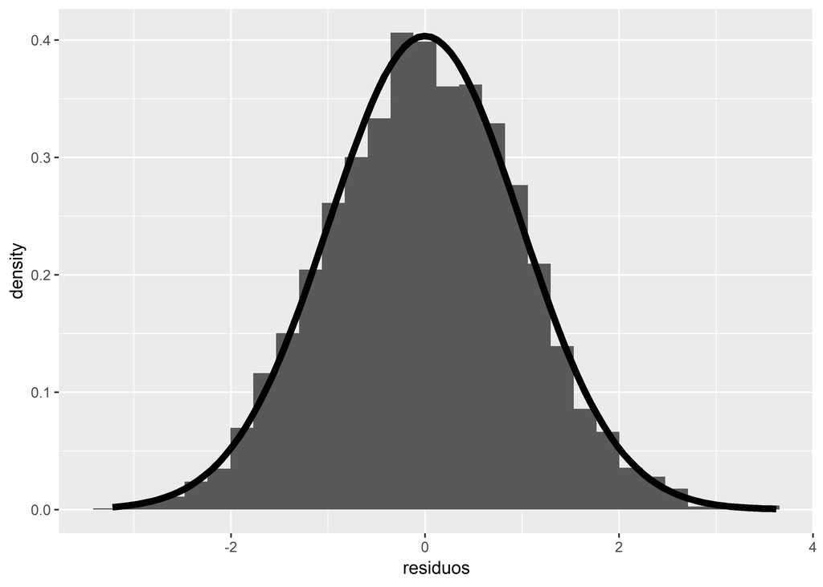

```r
library(dplyr)
library(ggplot2)

dados_residuos1 = data.frame(residuos = residuos1)

dados_residuos1  %>%
  ggplot(aes(x = residuos)) +
  geom_histogram(aes(y = ..density..)) +  # y = ..density.. para termos densidade
  stat_function(fun = "dnorm", # normal
                args = list(sd = sqrt(var(residuos1))), # desvio-padrão igual ao dos resíduos
                size = 2)
```

# Consistência assintótica do estimador de Mínimos Quadrados Ordinários

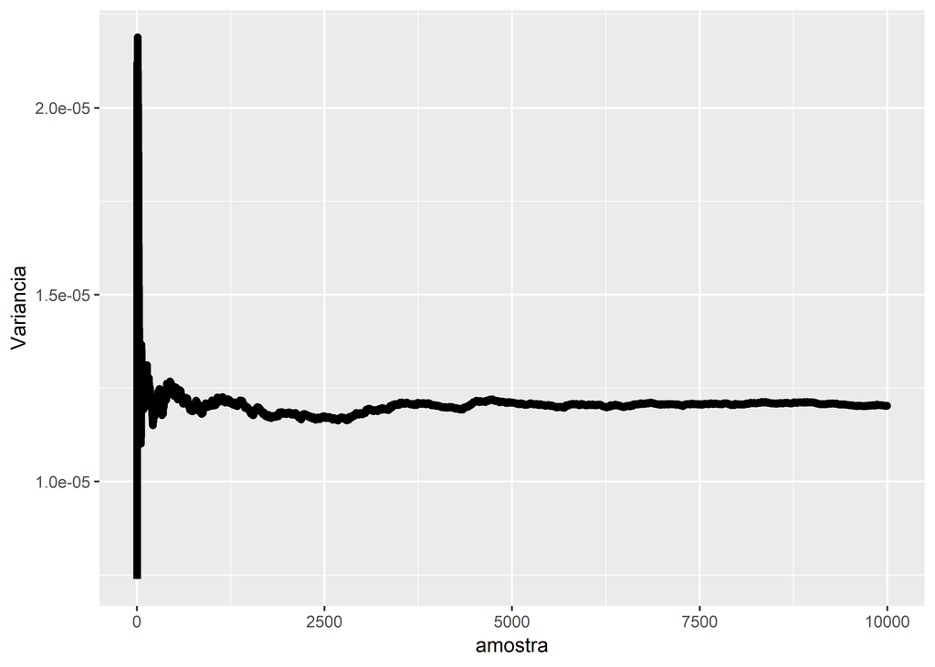

```r
parametros = vector() # vetor vazio que será preenchido
variancia_estimador = vector()
m = 10000 # tamanho máximos de amostra

for(i in 1:m) {

X = runif(n = m, min = 10, max = 20) # n = 2000 de uma variável aleatória X ~ U(10,20)
u = rnorm(n = m) # pertubações aleatórias com distribuição u ~ N(0,1)
Y = 5 + 0.8*X + u   # criamos Y a partir de X e u

dados = data.frame(explicada = Y,
                   explicativa = X)

modelo = lm(Y ~ X, # fórmula do modelo a ser estimado
             data = dados) # data.frame em que estão as variáveis

parametros[i] = coef(modelo)[2] # pegamos somente o parâmetro estimado para X
variancia_estimador[i] = var(parametros)

}

df_parametros = data.frame(Estimado = parametros,
                           Amostra = 1:m) #criamos um dataframe para o ggplot2
df_variancia = data.frame(Variancia = variancia_estimador,
                          amostra = 1:m)

df_variancia %>%
  ggplot(aes(x = amostra, y = Variancia)) +
  geom_line(size = 2)
```

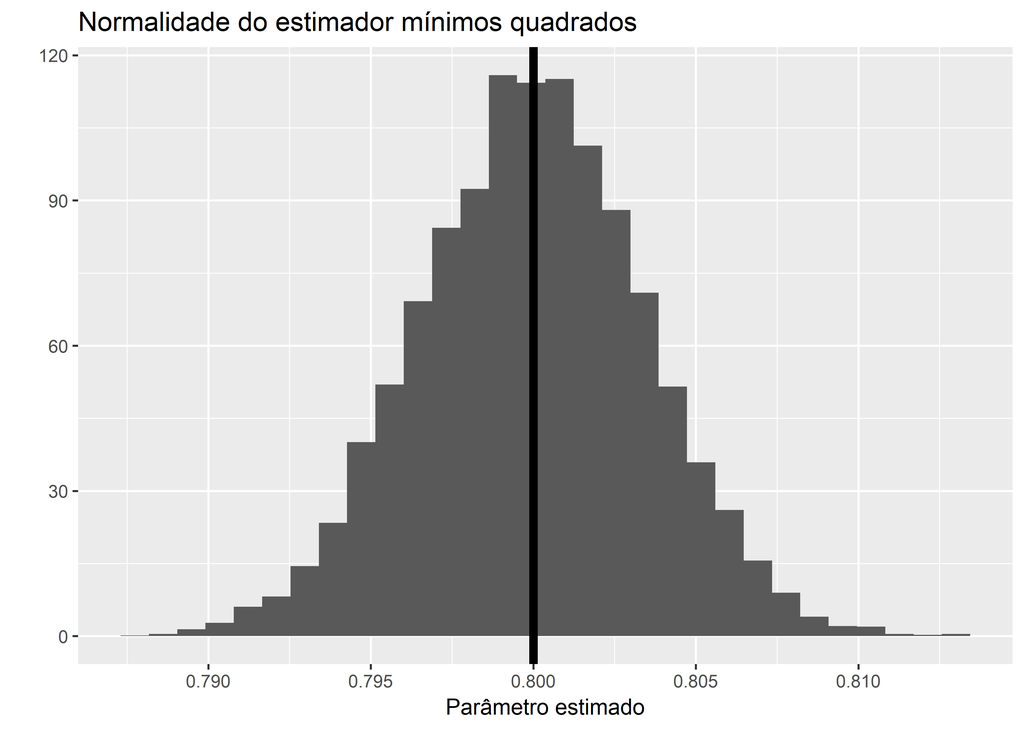

```r
df_parametros %>%
  ggplot(aes(x = Estimado)) +
  geom_histogram(aes(y = ..density..)) +
  geom_vline(xintercept = .8, # linha vertical no parâmetro verdadeiro
             size = 2) +
  ylab("") +
  xlab("Parâmetro estimado") +
  labs(title = "Normalidade do estimador mínimos quadrados")
```

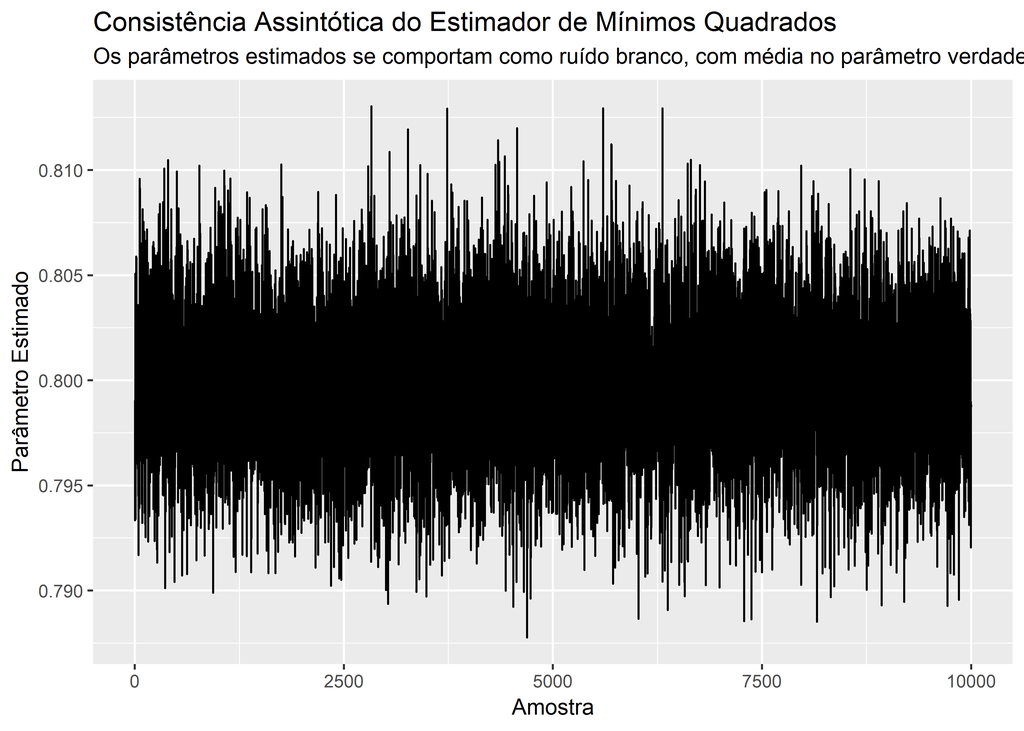

```r
df_parametros %>%
  ggplot(aes(x = Amostra, y = Estimado)) +
  geom_line() +
  ylab("Parâmetro Estimado") +
  labs(title = "Consistência Assintótica do Estimador de Mínimos Quadrados",
       subtitle = "Os parâmetros estimados se comportam como ruído branco, com média no parâmetro verdadeiro")
```

# Dados reais, Testes In-Sample/Out-of-Sample e alguns diagnósticos

Validar um modelo é importante, nem só de p-valor e R^2 vive o homem. Para isso, normalmente fazemos testes in-sampla/out-of-sample. A ideia é simples: estimamos um modelo em uma amostra dos dados e realizamos previsões em outra amostra para testar o quão preciso é o modelo. Vamos por partes.

Primeiro vamos importar dados, separar observações incompletas e depois divir a base em uma de treino e outra de teste. Existem várias maneiras de fazer isso, a mais simples é usar a função `sample()`. O problema desse método é que não garante uma divisão correta da base de dados pois uma mesma observação pode ser amostrada duas vezes seguidas. Um método mais interessante é gerar uma variável nova na base com uma distribuição conhecida - eu sempre uso Uniforme - e selecionar observações em que essa variável tenha um valor acima ou abaixo de um nível. Por exemplo, se essa variável tiver distribuição Uniforme entre 0 e 1, baste selecionar todas as observações com valores menores que 0.75 para que você separe aproximadamente 75% dos dados para treino e 25% para teste.

Uma nota de aviso sobre normalidade dos resíduos é que distribuições verdadeiramente normais não tem caudas. Em particular, o teste de Shapiro-Wilk irá prontamente rejeitar normalidade se houverem caudas nos dados, então é sempre de bom tom exlporar visualmente os resíduos e não confiar cegamente na estatística do teste.

```r
library(wooldridge)
data("wage2")

head(wage2)
```

```
##   wage hours  IQ KWW educ exper tenure age married black south urban sibs
## 1  769    40  93  35   12    11      2  31       1     0     0     1    1
## 2  808    50 119  41   18    11     16  37       1     0     0     1    1
## 3  825    40 108  46   14    11      9  33       1     0     0     1    1
## 4  650    40  96  32   12    13      7  32       1     0     0     1    4
## 5  562    40  74  27   11    14      5  34       1     0     0     1   10
## 6 1400    40 116  43   16    14      2  35       1     1     0     1    1
##   brthord meduc feduc    lwage
## 1       2     8     8 6.645091
## 2      NA    14    14 6.694562
## 3       2    14    14 6.715384
## 4       3    12    12 6.476973
## 5       6     6    11 6.331502
## 6       2     8    NA 7.244227
```

```r
wage2$completo = complete.cases(wage2) # vetor dizendo se a observação é completa
wage2 = wage2[wage2$completo == TRUE,]
wage2$separador = runif(n = nrow(wage2), min = 0, max = 1)

treino = wage2[wage2$separador < .75,]
teste = wage2[wage2$separador >= .75,]
```

Agora que temos dados separados podemos estimar um modelo na base de treino:

```r
modelo_salarios = lm(lwage ~ hours + IQ + educ + exper + tenure + south + urban + black,
                     data = treino)


summary(modelo_salarios)
```

```
##
## Call:
## lm(formula = lwage ~ hours + IQ + educ + exper + tenure + south +
##     urban + black, data = treino)
##
## Residuals:
##      Min       1Q   Median       3Q      Max
## -1.28232 -0.22499 -0.00299  0.22019  1.37538
##
## Coefficients:
##              Estimate Std. Error t value Pr(>|t|)
## (Intercept)  5.793415   0.193145  29.995  < 2e-16 ***
## hours       -0.009656   0.002353  -4.103 4.76e-05 ***
## IQ           0.003174   0.001326   2.394  0.01703 *
## educ         0.054467   0.009177   5.935 5.52e-09 ***
## exper        0.017731   0.004307   4.117 4.50e-05 ***
## tenure       0.008694   0.003202   2.716  0.00685 **
## south       -0.060299   0.034181  -1.764  0.07833 .
## urban        0.181547   0.035307   5.142 3.92e-07 ***
## black       -0.156403   0.057889  -2.702  0.00713 **
## ---
## Signif. codes:  0 '***' 0.001 '**' 0.01 '*' 0.05 '.' 0.1 ' ' 1
##
## Residual standard error: 0.3475 on 495 degrees of freedom
## Multiple R-squared:  0.2563, Adjusted R-squared:  0.2443
## F-statistic: 21.32 on 8 and 495 DF,  p-value: < 2.2e-16
```

```r
###### Analisando os resíduos
residuos_salarios = resid(modelo_salarios)

resid(modelo_salarios) %>% shapiro.test()
```

```
##
##  Shapiro-Wilk normality test
##
## data:  .
## W = 0.99496, p-value = 0.09947
```

O teste de Shapiro-Wilk não nos dá indícios de que não há normalidade nos resíduos, o que é bom.

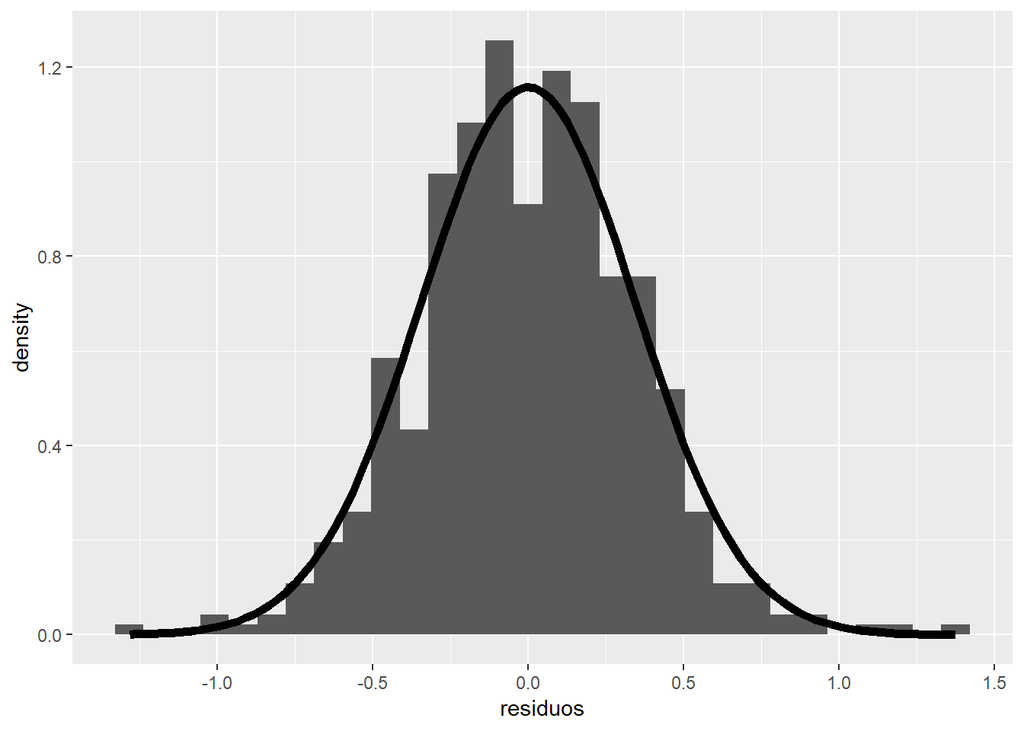

```r
dados_residuos_salarios = data.frame(residuos = residuos_salarios)

dados_residuos_salarios %>%
  ggplot(aes(x = residuos)) +
  geom_histogram(aes(y = ..density..)) +  # y = ..density.. para termos densidade
  stat_function(fun = "dnorm", # normal
                args = list(sd = sqrt(var(residuos_salarios))), # desvio-padrão igual ao dos resíduos
                size = 2)
```

Vamos agora avaliar a performance do nosso modelo. Para isso usaremos a função `predict.lm()`. Ela recebe um objeto em que armazenamos um modelo e dados de teste.

```r
teste$previsao = predict.lm(modelo_salarios, teste)
teste$erro = teste$lwage - teste$previsao

summary(teste$erro)
```

```
##     Min.  1st Qu.   Median     Mean  3rd Qu.     Max.
## -1.92929 -0.14698  0.06116  0.05297  0.29671  1.41760
```

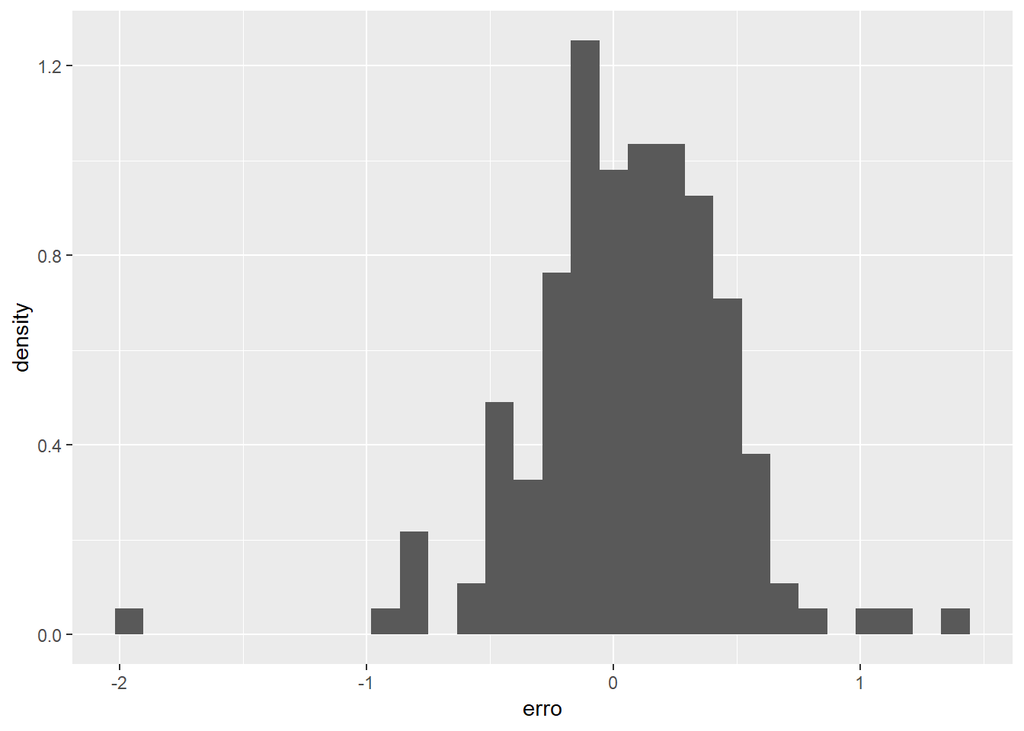

```r
teste %>%
  ggplot(aes(x = erro)) +
  geom_histogram(aes(y = ..density..))
```

Esse exercício tem interpretação mais clara quando estamos realizando exercícios econométricos de classificação, mas é bom saber que nosso modelo estimado na média tem erro próximo de zero.

# Regressão Descontínua

É plausível que dia de nascimento seja relevante para renda e escolaridade? Muito pouco a princípio, a menos que - por exemplo - um pai precise esperar um ano para matricular seu filho numa escola pública porque ele nasceu um dia depois da data limite para o ano. Essa é a ideia de [McCrary e Royer (2011, AER)](https://www.nber.org/papers/w12329). Esse tipo de evento não causa só variação plausivelmente exógena na escolaridade entre crianças, mas variação aguda. Uma descontinuidade, por assim dizer. O gráfico abaixo, tirado do paper, ilustra isso:

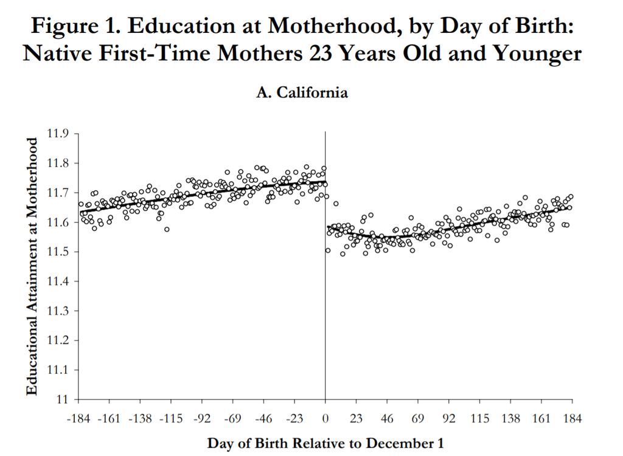

Esse desenho de pesquisa para estimar a diferença dos limites laterais no polinômio estimado é chamado de *Regression Discontinuity Design*, ou RDD. É uma técnica muito interessante porque normalmente estima o efeito *causal* de uma variável sobre outra e não somente uma correlação.

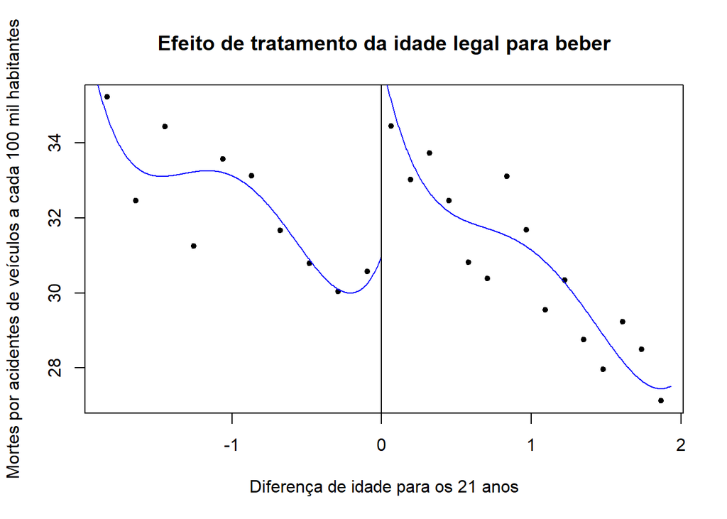

```r
library(rdrobust)
library(haven)
mortes = read_dta("http://masteringmetrics.com/wp-content/uploads/2015/01/AEJfigs.dta")

mortes$idade = mortes$agecell - 21 # diferença do grupo de idade ao nível do tratamento

rdplot(y = mortes$mva,
       x = mortes$idade,
       x.label = "Diferença de idade para os 21 anos",
       y.label = "Mortes por acidentes de veículos a cada 100 mil habitantes",
       title = "Efeito de tratamento da idade legal para beber")
```

# Sobre o que nós *não* falamos aqui

Não tocamos em diagnósticos de heterocedasticidade ou autocorrelação, muito menos em alguns modelos para séries temporais. Também não tocamos em modelos não-lineares com a função `nlm()`. Existe outra infinidade de assuntos que são interessantes.

A ideia é que o leitor, conhecendo a sintaxe e tendo alguns exemplos e modelos sendo estimados, consiga sozinho e com a ajuda do Google, aprender a rodar modelos novos e mais interessantes. No fundo é essa a mentalidade necessária para lidar com dados e programar.